# Customer Churn Analysis

```python
import pandas as pd
import numpy as np
```

### Read the dataset and change column names for easy access

```python
df = pd.read_csv('data.csv')
df.columns = df.columns.str.replace(' ','_').str.replace('#','no').str.lower()
df[:5]
```

|  | customer_id | first_time | recent_time | no_of_orders | no_of_orders_in_last_7_days | no_of_orders_in_last_4_weeks | amount | amount_in_last_7_days | amount_in_last_4_weeks | avg_distancefromresturant | avg_deliverytime |
| --- | --- | --- | --- | --- | --- | --- | --- | --- | --- | --- | --- |
| 0 | 1269647 | 6/29/15 10:57 | 12/10/15 2:18 | 212 | 6.0 | 43.0 | 138808 | 4291 | 26853 | 1.6 | 51 |
| 1 | 167631 | 7/4/15 15:39 | 12/15/15 14:42 | 211 | 8.0 | 19.0 | 56404 | 1925 | 4177 | 2.2 | 42 |
| 2 | 301524 | 6/26/15 9:56 | 12/9/15 20:45 | 189 | 9.0 | 33.0 | 36020 | 1772 | 6404 | 2.5 | 57 |
| 3 | 1268254 | 7/1/15 1:51 | 12/14/15 1:43 | 184 | 6.0 | 37.0 | 32489 | 975 | 7110 | 3.1 | 55 |
| 4 | 357161 | 7/11/15 18:34 | 12/19/15 23:26 | 182 | 4.0 | 23.0 | 85150 | 1738 | 9958 | 2.4 | 36 |

### Classify customers based on activity

Here, if a customer is inactive for 4 weeks, we classify him as a churned customer. And if the customer is inactive for 7 days, we chassify as inactive, and this means the customer may churn or may also become active later. After classifying we also check the customer counts in each of these categories.

```python
df['customer_type'] = 'active'
df.loc[pd.isna(df.no_of_orders_in_last_7_days),'customer_type'] = 'inactive'
df.loc[pd.isna(df.no_of_orders_in_last_4_weeks),'customer_type'] = 'churned'
dict(zip(*np.unique(df.customer_type, return_counts=True)))
```

```
{'active': 1923, 'churned': 5659, 'inactive': 2418}
```

### Check the activity data period

```python
df.first_time = pd.to_datetime(df.first_time, format='%m/%d/%y %H:%M').dt.date
df.recent_time = pd.to_datetime(df.recent_time, format='%m/%d/%y %H:%M').dt.date
df['active_days'] = (df.recent_time - df.first_time).dt.days + 1
df.recent_time.max(), df.first_time.min(), (df.recent_time.max()- df.first_time.min()).days
```

```
(datetime.date(2016, 1, 13), datetime.date(2015, 6, 5), 222)
```

##### From the above analysis we get to know that the data has 10000 samples of customer activity collected as of 13-01-2016

```python
df.loc[df.customer_type=='active','recent_time'].min(),df.loc[df.customer_type=='active','recent_time'].max()
```

```
(datetime.date(2015, 11, 10), datetime.date(2016, 1, 13))
```

Now we will drop the user details for which we do not have enough data. The customer should have done atleast 6 orders or must have been active for atleast 50 days. We are dropping the other customers as they would have availed the app for either using the joining offers.

```python
df1 = df.copy()
df = df[(df.no_of_orders>=6) | (df.active_days>=50)]
dict(zip(*np.unique(df.customer_type, return_counts=True)))
```

```
{'active': 1436, 'churned': 1452, 'inactive': 1383}
```

#### We see that a considerable number of rows are dropped and the number of custeomers is now 4271

Now Lets plot to understand the customer activity and checkout if we can find a way to differentiate the Churn and Active customers.

```python
df.hist(column='active_days',by='customer_type', bins=20)
```

```
array([[<matplotlib.axes._subplots.AxesSubplot object at 0x1108e0d30>,
      dtype=object)
```

```
array([[<matplotlib.axes._subplots.AxesSubplot object at 0x110b1cd30>,
      dtype=object)
```

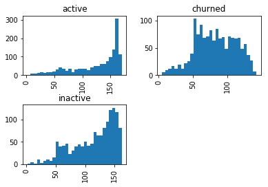

```python
df.hist(column='active_days',by='customer_type',bins=30)
```

```
array([[<matplotlib.axes._subplots.AxesSubplot object at 0x111075278>,
      dtype=object)
```

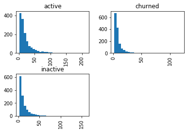

```python
df.hist(column='no_of_orders',by='customer_type', bins=30)
```

```
array([[<matplotlib.axes._subplots.AxesSubplot object at 0x110b1ccc0>,
      dtype=object)
```

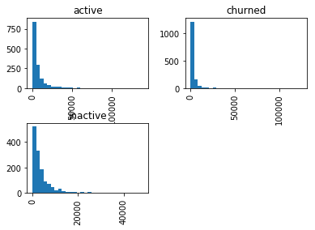

```python
df.hist(column='amount',by='customer_type', bins=30)
```

#### From the above 2 plots we could not identify any pattern. This might also mean that we might need to derive features to make sense. So we derive the below 2 features to understand Customer Activity better.

```python
df['avg_order_per_day'] = df['no_of_orders']/df['active_days']
df['avg_order_amount'] = df['amount']/df['no_of_orders']
```

```
array([[<matplotlib.axes._subplots.AxesSubplot object at 0x11150c668>,
      dtype=object)
```

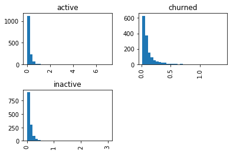

```python
df.hist(column='avg_order_per_day',by='customer_type', bins=30)
```

From the above graphs we can say that the average orders per day of an active customer ranges upto 6, whereas for a churned customer, this ranges only upto 1.2 orders per day. So if a customer starts showing inactivity, theres a high probability of churning out later than coming back.

```
array([[<matplotlib.axes._subplots.AxesSubplot object at 0x111731978>,
      dtype=object)
```

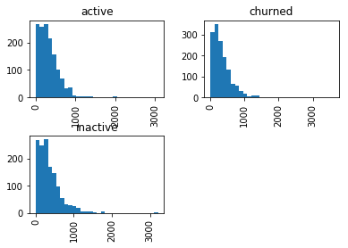

```python
df.hist(column='avg_order_amount',by='customer_type', bins=30)
```

The spending per order pattern doesn't seem to significantly vary between the active and churn customers.

## Getting The Total business with respect to cluster and churn status

```python
from pivottablejs import  pivot_ui
pivot_ui(df)
```

[interactive chart not shown]

## Getting the Active Days Pattern

```python
pivot_ui(df)
```

[interactive chart not shown]

```python
import plotly.plotly as py
import plotly
from plotly.offline import init_notebook_mode
import plotly.graph_objs as go
init_notebook_mode(connected=True)
import plotly.graph_objs as go
from sklearn.cluster import KMeans
from sklearn.preprocessing import MaxAbsScaler
mas = MaxAbsScaler()
```

## Clustering on the user activity pattern to group similar customers together

```python
# df['cluster'] = KMeans(n_clusters=4).fit_predict(mas.fit_transform(df[['active_days','avg_order_per_day','avg_order_amount']])).astype('str')
df['cluster'] = KMeans(n_clusters=4).fit_predict(df[['active_days','avg_order_per_day','avg_order_per_day','avg_order_amount']]).astype('str')
df['cluster'] = df['cluster'].map(lambda x: 'Cluster '+x)
```

```python
from sklearn.preprocessing import StandardScaler
```

```python
ss_1 = StandardScaler()
ss_2 = StandardScaler()
ss_1.fit(df.avg_order_per_day.values.reshape(-1,1))
ss_2.fit(df.avg_order_amount.values.reshape(-1,1))
```

```
StandardScaler(copy=True, with_mean=True, with_std=True)
```

```python
trace0 = go.Scatter(
    x = np.minimum(ss_1.transform(df.avg_order_per_day[df.customer_type=='active'].values.reshape(-1,1)).reshape(-1,),3),
    y = np.minimum(ss_2.transform(df.avg_order_amount[df.customer_type=='active'].values.reshape(-1,1)).reshape(-1,),4),
    name = 'Active',
    mode = 'markers',
    text = df.cluster[df.customer_type=='active'].values,
    hoverinfo = 'text'
)

trace1 = go.Scatter(
    x = np.minimum(ss_1.transform(df.avg_order_per_day[df.customer_type=='inactive'].values.reshape(-1,1)).reshape(-1,),3),
    y = np.minimum(ss_2.transform(df.avg_order_amount[df.customer_type=='inactive'].values.reshape(-1,1)).reshape(-1,),4),
    name = 'Inactive',
    mode = 'markers',
    text = df.cluster[df.customer_type=='active'].values,
    hoverinfo = 'text'
)

trace2 = go.Scatter(
    x = np.minimum(ss_1.transform(df.avg_order_per_day[df.customer_type=='churned'].values.reshape(-1,1)).reshape(-1,),3),
    y = np.minimum(ss_2.transform(df.avg_order_amount[df.customer_type=='churned'].values.reshape(-1,1)).reshape(-1,),4),
    name = 'Churned',
    mode = 'markers',
    text = df.cluster[df.customer_type=='active'].values,
    hoverinfo = 'text'
)

data = [trace0, trace1, trace2]

layout = dict(title = 'Distribution by activity',
              yaxis = dict(zeroline = True, title = 'Spend per Order'),
              xaxis = dict(zeroline = True,  title = 'Daily Order')
             )

fig = dict(data=data, layout=layout)
```

```python
plotly.offline.iplot(fig)
```

[interactive chart not shown]

```python
trace0 = go.Scatter(
    x = np.minimum(ss_1.transform(df.avg_order_per_day[df.cluster=='Cluster 1'].values.reshape(-1,1)).reshape(-1,),3),
    y = np.minimum(ss_2.transform(df.avg_order_amount[df.cluster=='Cluster 1'].values.reshape(-1,1)).reshape(-1,),4),
    name = 'Cluster 1',
    mode = 'markers',
    text = df.customer_type[df.cluster=='Cluster 1'].values,
    hoverinfo = 'text')

trace1 = go.Scatter(
    x = np.minimum(ss_1.transform(df.avg_order_per_day[df.cluster=='Cluster 2'].values.reshape(-1,1)).reshape(-1,),3),
    y = np.minimum(ss_2.transform(df.avg_order_amount[df.cluster=='Cluster 2'].values.reshape(-1,1)).reshape(-1,),4),
    name = 'Cluster 2',
    mode = 'markers',
    text = df.customer_type[df.cluster=='Cluster 2'].values,
    hoverinfo = 'text')

trace2 = go.Scatter(
    x = np.minimum(ss_1.transform(df.avg_order_per_day[df.cluster=='Cluster 3'].values.reshape(-1,1)).reshape(-1,),3),
    y = np.minimum(ss_2.transform(df.avg_order_amount[df.cluster=='Cluster 3'].values.reshape(-1,1)).reshape(-1,),4),
    name = 'Cluster 3',
    mode = 'markers',
    text = df.customer_type[df.cluster=='Cluster 3'].values,
    hoverinfo = 'text')

trace3 = go.Scatter(
    x = np.minimum(ss_1.transform(df.avg_order_per_day[df.cluster=='Cluster 0'].values.reshape(-1,1)).reshape(-1,),3),
    y = np.minimum(ss_2.transform(df.avg_order_amount[df.cluster=='Cluster 0'].values.reshape(-1,1)).reshape(-1,),4),
    name = 'Cluster 4',
    mode = 'markers',
    text = df.customer_type[df.cluster=='Cluster 0'].values,
    hoverinfo = 'text')

data = [trace0, trace1, trace2, trace3]

layout = dict(title = 'Distribution by Cluster',
              yaxis = dict(zeroline = True, title = 'Spend per Order'),
              xaxis = dict(zeroline = True,  title = 'Daily Order')
             )

fig = dict(data=data, layout=layout)
plotly.offline.iplot(fig)
```

[interactive chart not shown]

```python
from sklearn.decomposition import PCA
pca = PCA(n_components=2)
pca_df = pca.fit_transform(df[['active_days','avg_order_per_day','avg_order_per_day','avg_order_amount']])
```

```python
trace0 = go.Scatter(
    x = np.minimum(pca_df[df.cluster=='Cluster 1',0],1600),
    y = pca_df[df.cluster=='Cluster 1',1],
    name = 'Cluster 1',
    mode = 'markers',
    text = df.customer_type[df.cluster=='Cluster 1'].values,
    hoverinfo = 'text')

trace1 = go.Scatter(
    x = np.minimum(pca_df[df.cluster=='Cluster 2',0],1600),
    y = pca_df[df.cluster=='Cluster 2',1],
    name = 'Cluster 2',
    mode = 'markers',
    text = df.customer_type[df.cluster=='Cluster 2'].values,
    hoverinfo = 'text')

trace2 = go.Scatter(
    x = np.minimum(pca_df[df.cluster=='Cluster 3',0],1600),
    y = pca_df[df.cluster=='Cluster 3',1],
    name = 'Cluster 3',
    mode = 'markers',
    text = df.customer_type[df.cluster=='Cluster 3'].values,
    hoverinfo = 'text')

trace3 = go.Scatter(
    x = np.minimum(pca_df[df.cluster=='Cluster 0',0],1600),
    y = pca_df[df.cluster=='Cluster 0',1],
    name = 'Cluster 4',
    mode = 'markers',
    text = df.customer_type[df.cluster=='Cluster 0'].values,
    hoverinfo = 'text')

data = [trace0, trace1, trace2, trace3]

layout = dict(title = 'Distribution by Cluster',
              yaxis = dict(zeroline = True, title = 'PCA Features 1'),
              xaxis = dict(zeroline = True,  title = 'PCA Features 2')
             )

fig = dict(data=data, layout=layout)
plotly.offline.iplot(fig)
```

[interactive chart not shown]

```python
df.groupby(['cluster','customer_type'])['active_days','avg_order_per_day','avg_order_amount','avg_deliverytime'].mean()
```

| cluster | customer_type | active_days | avg_order_per_day | avg_order_amount | avg_deliverytime |
| --- | --- | --- | --- | --- | --- |
| Cluster 0 | active | 125.897727 | 0.181152 | 413.156171 | 36.558712 |
|  | churned | 83.012024 | 0.111284 | 413.331080 | 37.194389 |
|  | inactive | 116.804481 | 0.113400 | 410.752718 | 36.158859 |
| Cluster 1 | active | 125.994475 | 0.188835 | 141.595809 | 36.720994 |
|  | churned | 81.511229 | 0.125699 | 140.675738 | 36.475561 |
|  | inactive | 113.752212 | 0.129658 | 139.479775 | 36.635693 |
| Cluster 2 | active | 114.166667 | 0.125886 | 1723.492325 | 37.555556 |
|  | churned | 72.038462 | 0.095076 | 1545.882731 | 41.307692 |
|  | inactive | 104.045455 | 0.056210 | 1512.658265 | 35.500000 |
| Cluster 3 | active | 125.126506 | 0.156712 | 758.199301 | 37.921687 |
|  | churned | 86.611765 | 0.101283 | 776.807390 | 37.170588 |
|  | inactive | 113.072917 | 0.085155 | 809.954888 | 36.817708 |

```python
from sklearn.preprocessing import RobustScaler
rs_1 = RobustScaler()
rs_2 = RobustScaler()
rs_1.fit(df.avg_order_per_day.values.reshape(-1,1))
rs_2.fit(df.avg_order_amount.values.reshape(-1,1))

avg_order = df.avg_order_per_day.median()
avg_amount = df.avg_order_amount.median()


trace0 = go.Scatter(
    x = np.minimum(rs_1.transform(df.avg_order_per_day[(df.avg_order_per_day>=avg_order) & (df.avg_order_amount>=avg_amount)].values.reshape(-1,1)).reshape(-1,),3),
    y = np.minimum(rs_2.transform(df.avg_order_amount[(df.avg_order_per_day>=avg_order) & (df.avg_order_amount>=avg_amount)].values.reshape(-1,1)).reshape(-1,),4),
    name = 'Super Stars',
    mode = 'markers',
    text = df.customer_id[(df.avg_order_per_day>=avg_order) & (df.avg_order_amount>=avg_amount)].values,
    hoverinfo = 'text')

trace1 = go.Scatter(
    x = np.minimum(rs_1.transform(df.avg_order_per_day[(df.avg_order_per_day<avg_order) & (df.avg_order_amount>=avg_amount)].values.reshape(-1,1)).reshape(-1,),3),
    y = np.minimum(rs_2.transform(df.avg_order_amount[(df.avg_order_per_day<avg_order) & (df.avg_order_amount>=avg_amount)].values.reshape(-1,1)).reshape(-1,),4),
    name = 'Cash Cows',
    mode = 'markers',
    text = df.customer_id[(df.avg_order_per_day<avg_order) & (df.avg_order_amount>=avg_amount)].values,
    hoverinfo = 'text')

trace2 = go.Scatter(
    x = np.minimum(rs_1.transform(df.avg_order_per_day[(df.avg_order_per_day>=avg_order) & (df.avg_order_amount<avg_amount)].values.reshape(-1,1)).reshape(-1,),3),
    y = np.minimum(rs_2.transform(df.avg_order_amount[(df.avg_order_per_day>=avg_order) & (df.avg_order_amount<avg_amount)].values.reshape(-1,1)).reshape(-1,),4),
    name = 'Commoners',
    mode = 'markers',
    text = df.customer_id[(df.avg_order_per_day>=avg_order) & (df.avg_order_amount<avg_amount)].values,
    hoverinfo = 'text')

trace3 = go.Scatter(
    x = np.minimum(rs_1.transform(df.avg_order_per_day[(df.avg_order_per_day<avg_order) & (df.avg_order_amount<avg_amount)].values.reshape(-1,1)).reshape(-1,),3),
    y = np.minimum(rs_2.transform(df.avg_order_amount[(df.avg_order_per_day<avg_order) & (df.avg_order_amount<avg_amount)].values.reshape(-1,1)).reshape(-1,),4),
    name = 'Loaders',
    mode = 'markers',
    text = df.customer_id[(df.avg_order_per_day<avg_order) & (df.avg_order_amount<avg_amount)].values,
    hoverinfo = 'text')

data = [trace0, trace1, trace2, trace3]

layout = dict(title = 'Distribution by activity',
              yaxis = dict(zeroline = True, title = 'Spend per Order'),
              xaxis = dict(zeroline = True,  title = 'Daily Order')
             )

fig = dict(data=data, layout=layout)
plotly.offline.iplot(fig)
```

[interactive chart not shown]

The above graph classifies the customers into 4 groups based on their spending patterns. This means

- Super Stars - High Value customers who frequently use the app for orders
- Cash Cows - High Value customers who rarely use to order
- Commoners - Reliable customers who regularly order through the app, but mostly do only low to medium value transactions
- Loaders - These are customers who do rarely use the app and at the same time do only low value transactions

### Churn Status vs Delivery Time

Now We will se if the customers churn due to high delivery times. For this we use boxplot, and if we can see any significance, we can do a One way Anova test to confirm our hypothesis.

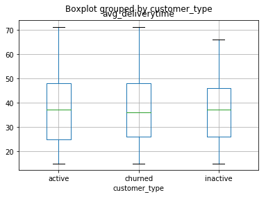

```python
df.boxplot(column='avg_deliverytime',by='customer_type')
```

There is no significant/observable difference in the Delivery time pattern for Active and Churn Customers.

### Anova Tests to see the variables that affect Churn Status

```python
import statsmodels
import statsmodels.api as sm
from statsmodels.formula.api import ols
```

```python
mod = ols('avg_deliverytime ~ customer_type', data=df).fit()
sm.stats.anova_lm(mod,typ=2)
```

|  | sum_sq | df | F | PR(>F) |
| --- | --- | --- | --- | --- |
| customer_type | 137.633295 | 2.0 | 0.411945 | 0.662387 |
| Residual | 712982.854647 | 4268.0 | NaN | NaN |

```python
mod = ols('avg_order_per_day ~ customer_type', data=df).fit()
sm.stats.anova_lm(mod,typ=2)
```

|  | sum_sq | df | F | PR(>F) |
| --- | --- | --- | --- | --- |
| customer_type | 3.973259 | 2.0 | 59.942386 | 2.119656e-26 |
| Residual | 141.451394 | 4268.0 | NaN | NaN |

```python
mod = ols('avg_order_amount ~ customer_type', data=df).fit()
sm.stats.anova_lm(mod,typ=2)
```

|  | sum_sq | df | F | PR(>F) |
| --- | --- | --- | --- | --- |
| customer_type | 2.854651e+05 | 2.0 | 1.72405 | 0.178467 |
| Residual | 3.533439e+08 | 4268.0 | NaN | NaN |

```python
mod = ols('avg_distancefromresturant ~ customer_type', data=df).fit()
sm.stats.anova_lm(mod,typ=2)
```

|  | sum_sq | df | F | PR(>F) |
| --- | --- | --- | --- | --- |
| customer_type | 0.246313 | 2.0 | 0.188702 | 0.82804 |
| Residual | 2785.511257 | 4268.0 | NaN | NaN |

From the above analysis we can say that only the Average Order per day affects the churn status for any customer. However the parameters like Distance From Restaurant and Average Delivery Time doesnt seem to affect.

## Modelling to Predict Customer Churn

We are predicting if a customer will churn using few features. As the Number of features is few, we use baleding of multiple models and the Bayesian Optimization for best training params.

```python
randoms = np.random.rand(4217)>0.25
train = df.loc[randoms].reset_index(drop=True)
test = df.loc[~randoms].reset_index(drop=True)
train.shape, test.shape
```

```
((3158, 16), (1059, 16))
```

```python
train.columns
```

```
Index(['customer_id', 'first_time', 'recent_time', 'no_of_orders',
       'no_of_orders_in_last_7_days', 'no_of_orders_in_last_4_weeks', 'amount',
       'amount_in_last_7_days', 'amount_in_last_4_weeks',
       'avg_distancefromresturant', 'avg_deliverytime', 'customer_type',
       'active_days', 'avg_order_per_day', 'avg_order_amount', 'cluster'],
      dtype='object')
```

```python
features_to_use = ['no_of_orders','amount','avg_deliverytime','avg_distancefromresturant','active_days', 'avg_order_per_day', 'avg_order_amount', 'cluster']
```

```python
x_train = pd.get_dummies(train[features_to_use])
y_train = (train.customer_type=='churned').astype(int)

x_test = pd.get_dummies(test[features_to_use])[x_train.columns]
y_test = (test.customer_type=='churned').astype(int)
```

```python
from lightgbm import LGBMClassifier
from sklearn.metrics import roc_auc_score
lgb_model = LGBMClassifier()
lgb_model.fit(x_train, y_train)
predicted_probabilities_lgb = lgb_model.predict_proba(x_test)[:,1]
print ('AUC ROC Score', roc_auc_score(y_test, predicted_probabilities_lgb))
```

```
AUC ROC Score 0.7630609062701801
```

```python
from catboost import CatBoostClassifier
cb_model = CatBoostClassifier(iterations=15)
cb_model.fit(x_train, y_train,plot=True)
predicted_probabilities_cb = cb_model.predict_proba(x_test)[:,1]
print ('AUC ROC Score', roc_auc_score(y_test, predicted_probabilities_cb))
```

```
0:	learn: 0.6773258	total: 94.2ms	remaining: 1.32s
1:	learn: 0.6595129	total: 131ms	remaining: 851ms
2:	learn: 0.6426243	total: 155ms	remaining: 619ms
3:	learn: 0.6248567	total: 176ms	remaining: 483ms
4:	learn: 0.6081831	total: 196ms	remaining: 392ms
5:	learn: 0.5994031	total: 215ms	remaining: 322ms
6:	learn: 0.5881266	total: 228ms	remaining: 260ms
7:	learn: 0.5772692	total: 243ms	remaining: 212ms
8:	learn: 0.5700178	total: 259ms	remaining: 172ms
9:	learn: 0.5584082	total: 275ms	remaining: 137ms
10:	learn: 0.5529975	total: 290ms	remaining: 106ms
11:	learn: 0.5445887	total: 307ms	remaining: 76.7ms
12:	learn: 0.5353433	total: 322ms	remaining: 49.6ms
13:	learn: 0.5312162	total: 335ms	remaining: 24ms
14:	learn: 0.5269506	total: 350ms	remaining: 0us
AUC ROC Score 0.7900273267077224
```

```python
from sklearn.ensemble import RandomForestClassifier
rf_model = RandomForestClassifier()
rf_model.fit(x_train,y_train)
predicted_probabilities_rf = rf_model.predict_proba(x_test)[:,1]
print ('AUC ROC Score', roc_auc_score(y_test, predicted_probabilities_rf))
```

```
AUC ROC Score 0.7535438093588068
```

```python
import time
import lightgbm as lgb
from bayes_opt import BayesianOptimization
import warnings
import time
warnings.filterwarnings("ignore")
def bayes_parameter_opt_lgb(X, y, init_round=15, opt_round=25, n_folds=5, random_seed=6, n_estimators=100, learning_rate=0.05, output_process=False):
    train_data = lgb.Dataset(data=X, label=y, free_raw_data=False)
    def lgb_eval(num_leaves, feature_fraction, bagging_fraction, max_depth, lambda_l1, lambda_l2, min_split_gain, min_child_weight):
        params = {'application':'binary','num_iterations': n_estimators, 'learning_rate':learning_rate, 'early_stopping_round':100, 'metric':'auc'}
        params["num_leaves"] = int(round(num_leaves))
        params['feature_fraction'] = max(min(feature_fraction, 1), 0)
        params['bagging_fraction'] = max(min(bagging_fraction, 1), 0)
        params['max_depth'] = int(round(max_depth))
        params['lambda_l1'] = max(lambda_l1, 0)
        params['lambda_l2'] = max(lambda_l2, 0)
        params['min_split_gain'] = min_split_gain
        params['min_child_weight'] = min_child_weight
        cv_result = lgb.cv(params, train_data, nfold=n_folds, seed=random_seed, stratified=True, verbose_eval =200, metrics=['auc'])
        return max(cv_result['auc-mean'])
    lgbBO = BayesianOptimization(lgb_eval, {'num_leaves': (24, 255),
                                            'feature_fraction': (0.1, 0.9),
                                            'bagging_fraction': (0.8, 1),
                                            'max_depth': (5, 8.99),
                                            'lambda_l1': (0, 5),
                                            'lambda_l2': (0, 3),
                                            'min_split_gain': (0.001, 0.1),
                                            'min_child_weight': (5, 50)}, random_state=42)
    lgbBO.maximize(init_points=init_round, n_iter=opt_round)
    if output_process==True: lgbBO.points_to_csv("bayes_opt_result.csv")
    return lgbBO.res['max']['max_params']
```

```python
opt_params = bayes_parameter_opt_lgb(x_train, y_train,init_round=20, opt_round=10, n_folds=5)
opt_params
```

```
Initialization
------------------------------------------------------------------------------------------------------------------------------------------------------------------------
 Step |   Time |      Value |   bagging_fraction |   feature_fraction |   lambda_l1 |   lambda_l2 |   max_depth |   min_child_weight |   min_split_gain |   num_leaves |
```

```
    1 | 00m00s |    0.80331 |             0.8244 |             0.5895 |      4.3155 |      0.0943 |      6.5508 |            48.3101 |           0.0809 |     110.5188 |
    2 | 00m00s |    0.79871 |             0.8990 |             0.2116 |      3.1165 |      1.9092 |      6.0827 |            16.3302 |           0.0897 |     243.6150 |
    3 | 00m00s |    0.79938 |             0.8069 |             0.3337 |      1.6545 |      0.9431 |      8.3067 |            27.3762 |           0.0325 |     193.0906 |
    4 | 00m00s |    0.79856 |             0.9819 |             0.3931 |      0.3178 |      1.5257 |      6.4234 |            18.5395 |           0.0119 |     162.2901 |
    5 | 00m00s |    0.80311 |             0.8518 |             0.4649 |      1.5549 |      2.7227 |      6.1209 |            17.8178 |           0.0236 |      60.0403 |
    6 | 00m00s |    0.79867 |             0.9325 |             0.7281 |      1.6259 |      0.7479 |      7.1654 |             6.6599 |           0.0433 |      60.0347 |
    7 | 00m00s |    0.79644 |             0.8623 |             0.2597 |      3.6480 |      1.2311 |      5.5623 |            32.4304 |           0.0820 |      37.4173 |
    8 | 00m00s |    0.80395 |             0.9040 |             0.5114 |      3.1878 |      2.2667 |      8.2008 |            27.6206 |           0.0862 |     224.0867 |
    9 | 00m00s |    0.80180 |             0.9093 |             0.5739 |      4.4361 |      0.6864 |      5.2975 |             7.3165 |           0.0017 |     162.8576 |
   10 | 00m00s |    0.80004 |             0.8370 |             0.1372 |      2.3611 |      0.2309 |      8.9377 |            17.5391 |           0.0516 |     187.5648 |
   11 | 00m00s |    0.80181 |             0.9939 |             0.5860 |      0.5980 |      0.8693 |      8.0813 |            45.8720 |           0.0423 |      28.7550 |
   12 | 00m00s |    0.79813 |             0.9550 |             0.2364 |      3.5662 |      0.4837 |      5.7929 |            15.7803 |           0.0230 |     248.0492 |
   13 | 00m00s |    0.79782 |             0.9879 |             0.1520 |      3.8039 |      2.7891 |      5.0220 |            11.5203 |           0.0129 |     216.2943 |
   14 | 00m00s |    0.80680 |             0.9790 |             0.8591 |      2.8064 |      2.4244 |      8.2537 |            27.0254 |           0.0344 |      73.0503 |
   15 | 00m00s |    0.80541 |             0.9196 |             0.8725 |      3.8548 |      1.9002 |      7.8204 |            49.3543 |           0.0943 |      66.0016 |
```

[output cut: 18 more lines]

```
{'num_leaves': 148.38427703815822,
 'feature_fraction': 0.8663878741505818,
 'bagging_fraction': 0.8119327836969791,
 'max_depth': 8.855958574585223,
 'lambda_l1': 4.833216831080235,
 'lambda_l2': 0.20300542476422012,
 'min_split_gain': 0.012050462823317776,
 'min_child_weight': 27.11386086442397}
```

```python
params = {'application':'binary','num_iterations': 100, 'learning_rate':0.05, 'metric':'auc'}
params["num_leaves"] = int(round(opt_params['num_leaves']))
params['feature_fraction'] = max(min(opt_params['feature_fraction'], 1), 0)
params['bagging_fraction'] = max(min(opt_params['bagging_fraction'], 1), 0)
params['max_depth'] = int(round(opt_params['max_depth']))
params['lambda_l1'] = max(opt_params['lambda_l1'], 0)
params['lambda_l2'] = max(opt_params['lambda_l2'], 0)
params['min_split_gain'] = opt_params['min_split_gain']
params['min_child_weight'] = opt_params['min_child_weight']
train_data = lgb.Dataset(data=x_train, label=y_train, free_raw_data=False)
lgb_bo_model = lgb.train(params, train_data)
predicted_probabilities_lgb_bo = lgb_bo_model.predict(x_test)
print ('AUC ROC Score', roc_auc_score(y_test, predicted_probabilities_lgb_bo))
```

```
AUC ROC Score 0.7920669858720133
```

```python
def blender(actual, all_predictions, iterations = 1000):
    all_predictions = np.array(all_predictions)
    n_predictors = len(all_predictions)
    all_weights = np.random.rand(iterations, n_predictors)
    all_weights = all_weights/all_weights.sum(axis=1).reshape(-1,1)
    all_scores = [roc_auc_score(actual,(weight*all_predictions.T).sum(axis=1)) for weight in all_weights]
    return all_weights[np.argmax(all_scores)], np.max(all_scores)
```

```python
from sklearn.linear_model import RidgeClassifier
rr_model = RidgeClassifier()
rr_model.fit(x_train,y_train)
predicted_probabilities_rr = rr_model.predict(x_test)
print ('AUC ROC Score', roc_auc_score(y_test, predicted_probabilities_rr))
```

```
AUC ROC Score 0.6424867304027343
```

```python
weights, final_auc = blender(y_test, [predicted_probabilities_lgb, predicted_probabilities_cb, predicted_probabilities_rf,predicted_probabilities_lgb_bo],10000)
```

The Plot below shows the weights given to various models

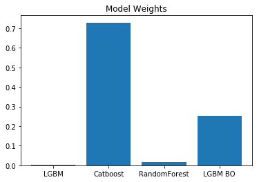

```python
from matplotlib import pyplot as plt
plt.bar(x = ['LGBM',
            'Catboost',
            'RandomForest',
            'LGBM BO'],
        height = weights)
plt.title('Model Weights')
plt.show()
```